# Devoir 2 - Régression Logisitique (GLM)

DANIEL GIAO (GIAD14029707)

01/05/2020

# INTRODUCTION

Nous avons à notre disposition, cette fois-ci, un ensemble de données sur des maisons vendues et encore une fois, nous voulons mettre en œuvre, sur ces vraies données, les techniques exposées dans les capsules vidéo du cours. Toutefois, la variable à expliquer est maintenant une variable dichotomique, c’est-à-dire, cette dernière est de nature qualitative et ne peut prendre que deux modalités possibles, par exemple « TRUE » ou « FALSE ». Autrement dit, au lieu de faire une prédiction sur une variable continue ou discrète, comme dans le cas du premier TP lorsque nous devons prédire la moyenne par habitant (100 000) de décès par cancer, nous devons prévoir cette fois-ci, en l’occurrence, la probabilité que les maisons vendues soient munies « Oui » ou « Non » d’un foyer. De plus, les observations tirées de cette base de données peuvent également être représentées graphiquement par un nuage de point. Cependant, contrairement au premier TP, nous ne s’intéresserons plus à tracer la droite linéaire qui s’ajuste le mieux possible à ce nuage de points. En revanche, nous s’intéresserons plutôt à tracer une courbe sigmoïde ayant la forme d’un « s » permettant de capturer les valeurs de « 0 » et de « 1 » qui s’ajuste le mieux possible à ce nuage de points. De ce fait, l’objectif principale du deuxième devoir de STT5100 est axé sur la construction d’un modèle de régression binomiale et plus précisément, une régression logistique. En effet, la régression logistique est un cas particulier de modèle linéaire généralisé (GLM). Par ailleurs, Il est crucial de préciser que la régression logistique ne consiste pas à modéliser la variable d’intérêt Y, mais plutôt la probabilité que celle-ci se réalise. Dans le cadre du projet, nous présenterons, en premier lieu, les variables qui pourraient potentiellement être intéressantes pour la construction du modèle. En deuxième lieu, nous expliquerons comment nous sommes parvenus, d’une part, à l’amélioration d’un modèle simple. D’autre part, nous allons également expliquer la méthode exploitée permettant de construire parallèlement un second modèle plus complexe et d’illustrer les moyens de le simplifier. En dernier lieu, nous comparerons les courbes ROC, ainsi que les valeurs AUC des deux modèles obtenus.

# PARTIE I

Dans cette partie exploratoire, nous présenterons les variables qui pourraient potentiellement être intéressantes pour la construction du modèle. Dans un premier temps, nous allons d’abord nous focaliser sur la base de données fournies. La base de données contient 723 observations sur des maisons vendues et 40 variables. Plus précisément, foyer est la variable d’intérêt et nous lui attribuons une valeur de « 1 » si la maison vendue possède effectivement un foyer et une valeur de « 0 », dans le cas contraire.

```r
code_permanent = "GIAD14029707"
loc_fichier = paste("http://freakonometrics.free.fr/",code_permanent,"H2020D2.RData",sep="")
download.file(loc_fichier, "base_devoir_2.RData")
load("base_devoir_2.RData")
dim(database)
```

```
## [1] 723  40
```

```r
str(database)
```

```
## 'data.frame':    723 obs. of  40 variables:
##  $ Zone              : Factor w/ 7 levels "A (agr)","C (all)",..: 6 7 6 6 6 6 6 7 6 6 ...
##  $ Surface_Lot       : int  8250 4426 10152 6970 10385 41600 11512 7596 8499 5001 ...
##  $ Rue               : Factor w/ 2 levels "Grvl","Pave": 2 2 2 2 2 2 2 2 2 2 ...
##  $ Forme             : Factor w/ 4 levels "IR1","IR2","IR3",..: 4 4 4 4 1 1 1 4 1 1 ...
##  $ Utilities         : Factor w/ 3 levels "AllPub","NoSeWa",..: 1 1 1 1 1 1 1 1 1 1 ...
##  $ Configuration     : Factor w/ 5 levels "Corner","CulDSac",..: 1 5 5 1 2 3 1 5 5 5 ...
##  $ Proxim_1          : Factor w/ 9 levels "Artery","Feedr",..: 3 3 3 2 3 3 3 1 3 3 ...
##  $ Proxim_2          : Factor w/ 8 levels "Artery","Feedr",..: 3 3 3 3 3 3 3 3 3 3 ...
##  $ Logement          : Factor w/ 5 levels "1Fam","2fmCon",..: 1 5 1 1 1 2 1 3 1 4 ...
##  $ Style             : Factor w/ 8 levels "1.5Fin","1.5Unf",..: 3 3 3 3 8 3 8 6 6 3 ...
##  $ Int_Qualite       : int  5 6 5 4 6 5 6 5 6 7 ...
##  $ Int_Condition     : int  7 5 5 5 6 5 7 5 5 5 ...
##  $ Construction_Annee: int  1963 2004 1956 1961 1978 1969 1959 1952 2006 2007 ...
##  $ Renovation_Annee  : int  1963 2004 1956 1961 1978 1990 2006 1952 2007 2008 ...
```

[output cut: 26 more lines]

```r
table(database$foyer)
```

```
##
##   0   1
## 357 366
```

```r
DF=database
```

## (1.1) SÉLECTION DE VARIABLES EXPLICATIVES INTÉRESSANTES

Dans un deuxième temps, nous allons procéder à la sélection des variables explicatives. Pour se faire, nous allons commencer par le traitement des variables qualitatives et par la suite, les variables quantitatives.

Parmi les 39 autres variables explicatives, nous avons vingt-trois variables catégorielles. En effet, ces deux variables de type catégorielle comportent individuellement plusieurs modalités et nous pose certes un véritable problème parce que chaque modalité nous ajoute une variable explicative de plus à considérer pour la modélisation. Par exemple, la variable Zone contient 7 modalités et par conséquent, nous devons considérer 7 variables explicatives de plus. Pour y remédier, nous allons les regrouper efficacement les modalités afin de simplifier la procédure de sélection de variables explicatives à l’aide des boîtes à moustaches et du test de Wald.

### (1.1.1) Zone

Afin d’obtenir la visualisation la plus nette possible à notre boîte à moustaches, nous avons commencé par réordonner les modalités en prenant comme référence la zone ayant pas de foyer. Plus précisément, la zone C est notre modalité de référence.

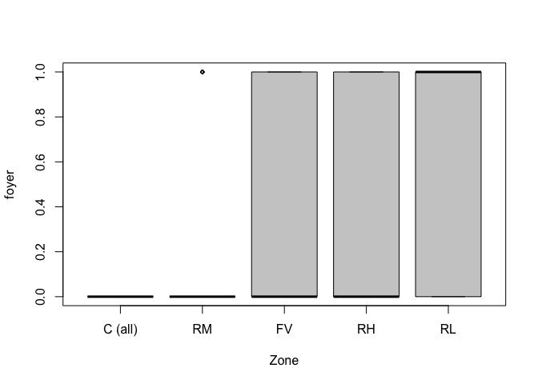

```r
A = with(data = DF, aggregate(foyer,by=list(Zone),FUN=mean))
A = A[order(A$x),]
L = as.character(A$Group.1)
DF$Zone= factor(DF$Zone, level=L)
with(data = DF, boxplot(foyer~Zone,cex=.5,col=grey(.8)))
```

```r
reg_Zone = glm(foyer~Zone,data = DF,family = binomial(link = "logit"))
summary(reg_Zone)
```

```
##
## Call:
## glm(formula = foyer ~ Zone, family = binomial(link = "logit"),
##     data = DF)
##
## Deviance Residuals:
##    Min      1Q  Median      3Q     Max
## -1.309  -1.309   1.051   1.051   1.704
##
## Coefficients:
##             Estimate Std. Error z value Pr(>|z|)
## (Intercept)   -14.57     441.37  -0.033    0.974
## ZoneRM         13.38     441.37   0.030    0.976
## ZoneFV         13.78     441.37   0.031    0.975
## ZoneRH         13.87     441.37   0.031    0.975
## ZoneRL         14.87     441.37   0.034    0.973
##
## (Dispersion parameter for binomial family taken to be 1)
##
##     Null deviance: 1002.18  on 722  degrees of freedom
## Residual deviance:  945.39  on 718  degrees of freedom
## AIC: 955.39
##
## Number of Fisher Scoring iterations: 13
```

Nous allons effectuer un test multiple afin de tester si les 3 zones suivants ont effectivement des coefficients nuls dans la régression logistique : RM, FV et RH. De ce fait, nous allons procéder avec un test de Wald. Le statistique de Wald est faible avec une p-value de 0.8023. Nous allons donc regrouper ces trois modalités.

```r
library(car)
linearHypothesis(reg_Zone, c("ZoneRM = 0",
                              "ZoneFV = 0",
                              "ZoneRH = 0"))
```

```
## Linear hypothesis test
##
## Hypothesis:
## ZoneRM = 0
## ZoneFV = 0
## ZoneRH = 0
##
## Model 1: restricted model
## Model 2: foyer ~ Zone
##
##   Res.Df Df  Chisq Pr(>Chisq)
## 1    721
## 2    718  3 0.9956     0.8023
```

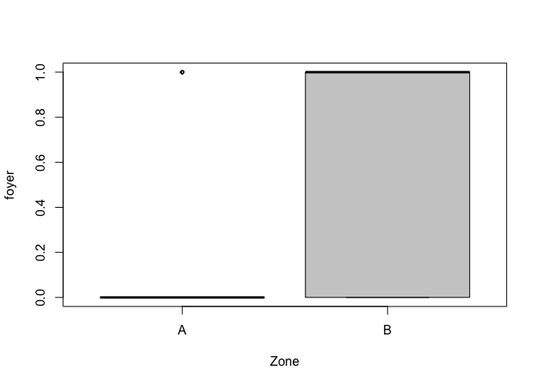

```r
levels(DF$Zone) = c(rep("A",4),"B")
DF$Zone = relevel(DF$Zone,"A")
with(data = DF, boxplot(foyer~Zone,cex=.5,col=grey(.8)))
```

```r
reg_Zone = glm(foyer~Zone,data = DF,family = binomial(link = "logit"))
summary(reg_Zone)
```

```
##
## Call:
## glm(formula = foyer ~ Zone, family = binomial(link = "logit"),
##     data = DF)
##
## Deviance Residuals:
##    Min      1Q  Median      3Q     Max
## -1.309  -1.309   1.051   1.051   1.669
##
## Coefficients:
##             Estimate Std. Error z value Pr(>|z|)
## (Intercept)  -1.1073     0.1871  -5.918 3.26e-09 ***
## ZoneB         1.4114     0.2054   6.871 6.36e-12 ***
## ---
## Signif. codes:  0 '***' 0.001 '**' 0.01 '*' 0.05 '.' 0.1 ' ' 1
##
## (Dispersion parameter for binomial family taken to be 1)
##
##     Null deviance: 1002.18  on 722  degrees of freedom
## Residual deviance:  948.69  on 721  degrees of freedom
## AIC: 952.69
##
## Number of Fisher Scoring iterations: 4
```

Enfin, nous avons réussi à réduire le nombre de modalités pour la variable Zone et nous nous retrouvons avec les deux sous-groupes suivants : ZoneA et ZoneB. Par ailleurs, nous constatons qu’elle s’avère très significative dans la régression logistique. De ce fait, la variable Zone est intéressante en raison de sa faible p-value et nous allons la retenir pour la construction du modèle.

Où

ZoneA = {C, RM, FV, RH}

ZoneB = {RL}

### (1.1.2) Forme

Par la suite, nous allons procéder au regroupement de la variable Forme similairement à la méthode utilisée pour combiner les modalités de la variable Zone, c’est-à-dire à l’aide des boîtes à moustaches et du test de Wald.

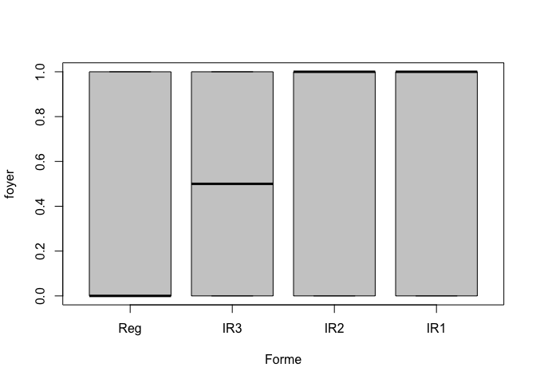

```r
A = with(data = DF, aggregate(foyer,by=list(Forme),FUN=mean))
A = A[order(A$x),]
L = as.character(A$Group.1)
DF$Forme= factor(DF$Forme, level=L)
with(data = DF, boxplot(foyer~Forme,cex=.5,col=grey(.8)))
```

```r
reg_Forme = glm(foyer~Forme,data = DF,family = binomial(link = "logit"))
summary(reg_Forme)
```

```
##
## Call:
## glm(formula = foyer ~ Forme, family = binomial(link = "logit"),
##     data = DF)
##
## Deviance Residuals:
##     Min       1Q   Median       3Q      Max
## -1.5417  -1.0235   0.8526   1.3395   1.3395
##
## Coefficients:
##             Estimate Std. Error z value Pr(>|z|)
## (Intercept) -0.37338    0.09427  -3.961 7.47e-05 ***
## FormeIR3     0.37338    1.41735   0.263   0.7922
## FormeIR2     0.74110    0.44376   1.670   0.0949 .
## FormeIR1     1.19829    0.17072   7.019 2.23e-12 ***
## ---
## Signif. codes:  0 '***' 0.001 '**' 0.01 '*' 0.05 '.' 0.1 ' ' 1
##
## (Dispersion parameter for binomial family taken to be 1)
##
##     Null deviance: 1002.18  on 722  degrees of freedom
## Residual deviance:  949.09  on 719  degrees of freedom
## AIC: 957.09
##
## Number of Fisher Scoring iterations: 4
```

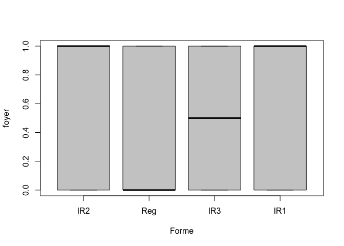

```r
DF$Forme = relevel(DF$Forme,"IR2")
with(data = DF, boxplot(foyer~Forme,cex=.5,col=grey(.8)))
```

```r
reg_Forme = glm(foyer~Forme,data = DF,family = binomial(link = "logit"))
summary(reg_Forme)
```

```
##
## Call:
## glm(formula = foyer ~ Forme, family = binomial(link = "logit"),
##     data = DF)
##
## Deviance Residuals:
##     Min       1Q   Median       3Q      Max
## -1.5417  -1.0235   0.8526   1.3395   1.3395
##
## Coefficients:
##             Estimate Std. Error z value Pr(>|z|)
## (Intercept)   0.3677     0.4336   0.848   0.3964
## FormeReg     -0.7411     0.4438  -1.670   0.0949 .
## FormeIR3     -0.3677     1.4792  -0.249   0.8037
## FormeIR1      0.4572     0.4564   1.002   0.3165
## ---
## Signif. codes:  0 '***' 0.001 '**' 0.01 '*' 0.05 '.' 0.1 ' ' 1
##
## (Dispersion parameter for binomial family taken to be 1)
##
##     Null deviance: 1002.18  on 722  degrees of freedom
## Residual deviance:  949.09  on 719  degrees of freedom
## AIC: 957.09
##
## Number of Fisher Scoring iterations: 4
```

```r
library(car)
linearHypothesis(reg_Forme, c("FormeIR3 = 0",
                              "FormeIR1 = 0"))
```

```
## Linear hypothesis test
##
## Hypothesis:
## FormeIR3 = 0
## FormeIR1 = 0
##
## Model 1: restricted model
## Model 2: foyer ~ Forme
##
##   Res.Df Df  Chisq Pr(>Chisq)
## 1    721
## 2    719  2 1.3053     0.5207
```

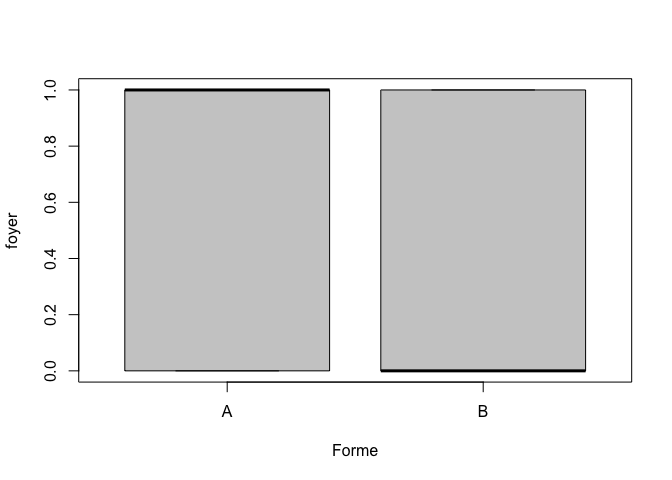

```r
levels(DF$Forme) = c("A","B",rep("A",2))
DF$Forme = relevel(DF$Forme,"A")
with(data = DF, boxplot(foyer~Forme,cex=.5,col=grey(.8)))
```

```r
reg_Forme = glm(foyer~Forme,data = DF,family = binomial(link = "logit"))
summary(reg_Forme)
```

```
##
## Call:
## glm(formula = foyer ~ Forme, family = binomial(link = "logit"),
##     data = DF)
##
## Deviance Residuals:
##     Min       1Q   Median       3Q      Max
## -1.5196  -1.0235   0.8702   1.3395   1.3395
##
## Coefficients:
##             Estimate Std. Error z value Pr(>|z|)
## (Intercept)   0.7760     0.1343   5.780 7.48e-09 ***
## FormeB       -1.1494     0.1641  -7.006 2.45e-12 ***
## ---
## Signif. codes:  0 '***' 0.001 '**' 0.01 '*' 0.05 '.' 0.1 ' ' 1
##
## (Dispersion parameter for binomial family taken to be 1)
##
##     Null deviance: 1002.18  on 722  degrees of freedom
## Residual deviance:  950.36  on 721  degrees of freedom
## AIC: 954.36
##
## Number of Fisher Scoring iterations: 4
```

Ainsi, nous avons réussi à réduire le nombre de modalités pour la variable Forme et nous nous retrouvons avec les deux sous-groupes suivants : FormeA et FormeB. Par ailleurs, nous constatons qu’elle s’avère très significative dans la régression logistique. De ce fait, la variable Forme est très intéressante en raison de sa faible p-value et nous allons la retenir pour la construction du modèle.

Où

FormeA = {IR1, IR2, IR3}

FormeB = {Reg}

### (1.1.3) Utilities

Nous n’avons pas procédé au regroupement des modalités de la variable Utilities, car il n’y avait que deux modalités et donc, ce n’était pas nécessaire.

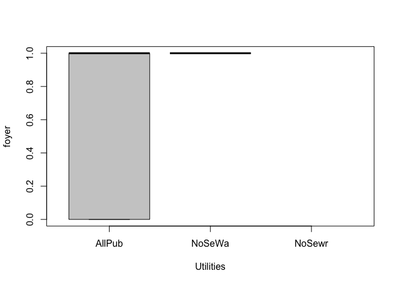

```r
with(data = DF, boxplot(foyer~Utilities,cex=.5,col=grey(.8)))
```

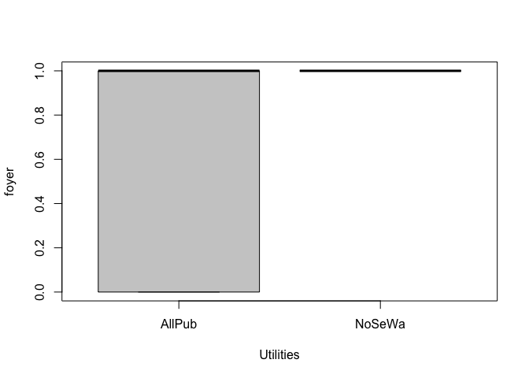

```r
A = with(data = DF, aggregate(foyer,by=list(Utilities),FUN=mean))
A = A[order(A$x),]
L = as.character(A$Group.1)
DF$Utilities= factor(DF$Utilities, level=L)
with(data = DF, boxplot(foyer~Utilities,cex=.5,col=grey(.8)))
```

```r
reg_Utilies = glm(foyer~Utilities,data = DF,family = binomial(link = "logit"))
summary(reg_Utilies)
```

```
##
## Call:
## glm(formula = foyer ~ Utilities, family = binomial(link = "logit"),
##     data = DF)
##
## Deviance Residuals:
##    Min      1Q  Median      3Q     Max
## -1.187  -1.187   1.168   1.168   1.168
##
## Coefficients:
##                  Estimate Std. Error z value Pr(>|z|)
## (Intercept)       0.02216    0.07444   0.298    0.766
## UtilitiesNoSeWa  13.54390  535.41117   0.025    0.980
##
## (Dispersion parameter for binomial family taken to be 1)
##
##     Null deviance: 1002.2  on 722  degrees of freedom
## Residual deviance: 1000.8  on 721  degrees of freedom
## AIC: 1004.8
##
## Number of Fisher Scoring iterations: 12
```

Enfin, nous constatons que la variable Utilities ne s’avère pas significative dans la régression logistique. Par conséquent, la variable Utilities n’est pas intéressante en raison de p-value trop élevé et nous n’allons pas la retenir pour la construction du modèle.

### (1.1.4) Configuration

Encore une fois, nous allons procéder au regroupement de la variable Configuration similairement à la méthode utilisée pour combiner les modalités de la variable Zone, c’est-à-dire à l’aide des boîtes à moustaches et du test de Wald.

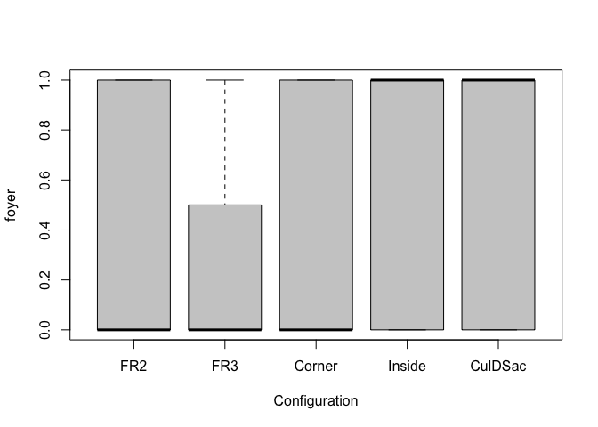

```r
A = with(data = DF, aggregate(foyer,by=list(Configuration),FUN=mean))
A = A[order(A$x),]
L = as.character(A$Group.1)
DF$Configuration= factor(DF$Configuration, level=L)
with(data = DF, boxplot(foyer~Configuration,cex=.5,col=grey(.8)))
```

```r
reg_Configuration  = glm(foyer~Configuration ,data = DF,family = binomial(link = "logit"))
summary(reg_Configuration )
```

```
##
## Call:
## glm(formula = foyer ~ Configuration, family = binomial(link = "logit"),
##     data = DF)
##
## Deviance Residuals:
##     Min       1Q   Median       3Q      Max
## -1.6369  -1.1822   0.7793   1.1726   1.5829
##
## Coefficients:
##                      Estimate Std. Error z value Pr(>|z|)
## (Intercept)           -0.9163     0.4830  -1.897  0.05784 .
## ConfigurationFR3       0.2231     1.3166   0.169  0.86541
## ConfigurationCorner    0.8538     0.5144   1.660  0.09697 .
## ConfigurationInside    0.9276     0.4908   1.890  0.05876 .
## ConfigurationCulDSac   1.9524     0.5971   3.270  0.00108 **
## ---
## Signif. codes:  0 '***' 0.001 '**' 0.01 '*' 0.05 '.' 0.1 ' ' 1
##
## (Dispersion parameter for binomial family taken to be 1)
##
##     Null deviance: 1002.2  on 722  degrees of freedom
## Residual deviance:  987.9  on 718  degrees of freedom
## AIC: 997.9
##
## Number of Fisher Scoring iterations: 4
```

```r
library(car)
linearHypothesis(reg_Configuration, c("ConfigurationFR3  = 0"))
```

```
## Linear hypothesis test
##
## Hypothesis:
## ConfigurationFR3 = 0
##
## Model 1: restricted model
## Model 2: foyer ~ Configuration
##
##   Res.Df Df  Chisq Pr(>Chisq)
## 1    719
## 2    718  1 0.0287     0.8654
```

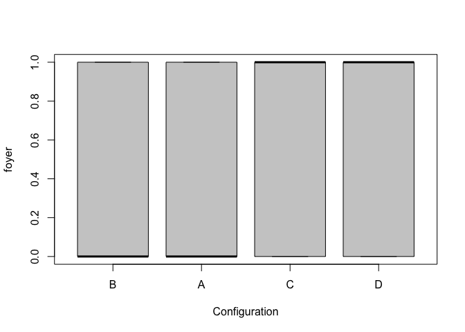

```r
levels(DF$Configuration) = c(rep("A",2),"B","C","D")
DF$Configuration = relevel(DF$Configuration,"B")
with(data = DF, boxplot(foyer~Configuration,cex=.5,col=grey(.8)))
```

```r
reg_Configuration = glm(foyer~Configuration,data = DF,family = binomial(link = "logit"))
summary(reg_Configuration)
```

```
##
## Call:
## glm(formula = foyer ~ Configuration, family = binomial(link = "logit"),
##     data = DF)
##
## Deviance Residuals:
##     Min       1Q   Median       3Q      Max
## -1.6369  -1.1822   0.7793   1.1726   1.5698
##
## Coefficients:
##                Estimate Std. Error z value Pr(>|z|)
## (Intercept)    -0.06252    0.17686  -0.353  0.72372
## ConfigurationA -0.82478    0.48266  -1.709  0.08748 .
## ConfigurationC  0.07386    0.19708   0.375  0.70783
## ConfigurationD  1.09861    0.39300   2.795  0.00518 **
## ---
## Signif. codes:  0 '***' 0.001 '**' 0.01 '*' 0.05 '.' 0.1 ' ' 1
##
## (Dispersion parameter for binomial family taken to be 1)
##
##     Null deviance: 1002.18  on 722  degrees of freedom
## Residual deviance:  987.93  on 719  degrees of freedom
## AIC: 995.93
##
## Number of Fisher Scoring iterations: 4
```

```r
library(car)
linearHypothesis(reg_Configuration, c("ConfigurationC  = 0"))
```

```
## Linear hypothesis test
##
## Hypothesis:
## ConfigurationC = 0
##
## Model 1: restricted model
## Model 2: foyer ~ Configuration
##
##   Res.Df Df  Chisq Pr(>Chisq)
## 1    720
## 2    719  1 0.1405     0.7078
```

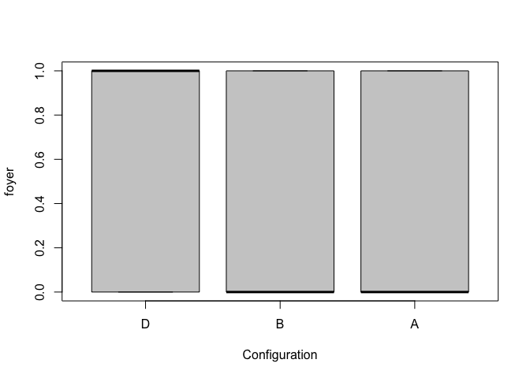

```r
levels(DF$Configuration) = c("B","A","B","D")
DF$Configuration = relevel(DF$Configuration,"D")
with(data = DF, boxplot(foyer~Configuration,cex=.5,col=grey(.8)))
```

```r
reg_Configuration = glm(foyer~Configuration,data = DF,family = binomial(link = "logit"))
summary(reg_Configuration)
```

```
##
## Call:
## glm(formula = foyer ~ Configuration, family = binomial(link = "logit"),
##     data = DF)
##
## Deviance Residuals:
##     Min       1Q   Median       3Q      Max
## -1.6369  -1.1761   0.7793   1.1787   1.5698
##
## Coefficients:
##                Estimate Std. Error z value Pr(>|z|)
## (Intercept)      1.0361     0.3510   2.952 0.003155 **
## ConfigurationB  -1.0391     0.3595  -2.890 0.003848 **
## ConfigurationA  -1.9234     0.5700  -3.375 0.000739 ***
## ---
## Signif. codes:  0 '***' 0.001 '**' 0.01 '*' 0.05 '.' 0.1 ' ' 1
##
## (Dispersion parameter for binomial family taken to be 1)
##
##     Null deviance: 1002.18  on 722  degrees of freedom
## Residual deviance:  988.07  on 720  degrees of freedom
## AIC: 994.07
##
## Number of Fisher Scoring iterations: 4
```

Ainsi, nous avons réussi à réduire le nombre de modalités pour la variable Configuration et nous nous retrouvons avec les trois sous-groupes suivants : ConfigurationA, ConfigurationB et ConfigurationD. Par ailleurs, nous constatons qu’elle s’avère significative dans la régression logistique. De ce fait, la variable Configuration est intéressante en raison de sa faible p-value et nous allons la retenir pour la construction du modèle.

Où

ConfigurationA = {FR2, FR3}

ConfigurationB = {Corner, Inside}

ConfigurationD = {CulDSac}

### (1.1.5) Proxim_1

Par la suite, nous allons procéder au regroupement de la variable Proxim_1 similairement à la méthode utilisée pour combiner les modalités de la variable Zone, c’est-à-dire à l’aide des boîtes à moustaches et du test de Wald.

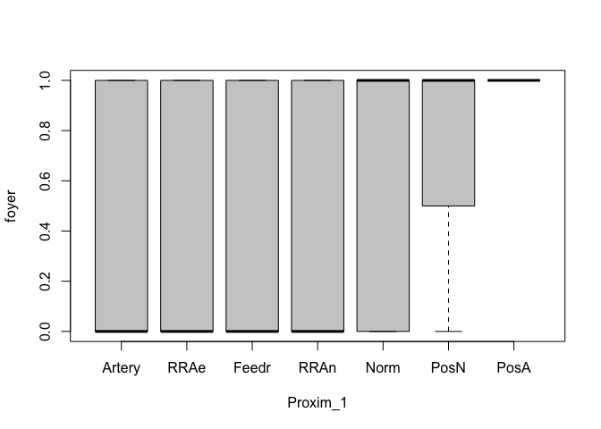

```r
A = with(data = DF, aggregate(foyer,by=list(Proxim_1),FUN=mean))
A = A[order(A$x),]
L = as.character(A$Group.1)
DF$Proxim_1= factor(DF$Proxim_1, level=L)
with(data = DF, boxplot(foyer~Proxim_1,cex=.5,col=grey(.8)))
```

```r
reg_Proxim_1  = glm(foyer~Proxim_1 ,data = DF,family = binomial(link = "logit"))
summary(reg_Proxim_1 )
```

```
##
## Call:
## glm(formula = foyer ~ Proxim_1, family = binomial(link = "logit"),
##     data = DF)
##
## Deviance Residuals:
##     Min       1Q   Median       3Q      Max
## -1.6651  -1.1991   0.7585   1.1559   1.4823
##
## Coefficients:
##                 Estimate Std. Error z value Pr(>|z|)
## (Intercept)   -6.931e-01  4.629e-01  -1.497   0.1343
## Proxim_1RRAe   3.054e-15  8.452e-01   0.000   1.0000
## Proxim_1Feedr  4.700e-01  5.717e-01   0.822   0.4110
## Proxim_1RRAn   5.596e-01  6.944e-01   0.806   0.4203
## Proxim_1Norm   7.440e-01  4.697e-01   1.584   0.1132
## Proxim_1PosN   1.792e+00  9.386e-01   1.909   0.0563 .
## Proxim_1PosA   1.526e+01  4.414e+02   0.035   0.9724
## ---
## Signif. codes:  0 '***' 0.001 '**' 0.01 '*' 0.05 '.' 0.1 ' ' 1
##
## (Dispersion parameter for binomial family taken to be 1)
##
##     Null deviance: 1002.18  on 722  degrees of freedom
## Residual deviance:  990.34  on 716  degrees of freedom
## AIC: 1004.3
##
## Number of Fisher Scoring iterations: 13
```

```r
library(car)
linearHypothesis(reg_Proxim_1, c("Proxim_1RRAe  = 0",
                                 "Proxim_1Feedr = 0",
                                 "Proxim_1RRAn = 0"))
```

```
## Linear hypothesis test
##
## Hypothesis:
## Proxim_1RRAe = 0
## Proxim_1Feedr = 0
## Proxim_1RRAn = 0
##
## Model 1: restricted model
## Model 2: foyer ~ Proxim_1
##
##   Res.Df Df  Chisq Pr(>Chisq)
## 1    719
## 2    716  3 1.0966     0.7779
```

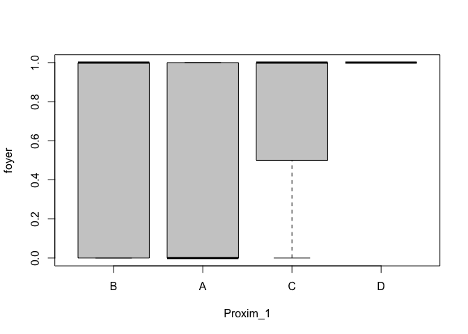

```r
levels(DF$Proxim_1) = c(rep("A",4),"B","C","D")
DF$Proxim_1 = relevel(DF$Proxim_1,"B")
with(data = DF, boxplot(foyer~Proxim_1,cex=.5,col=grey(.8)))
```

```r
reg_Proxim_1 = glm(foyer~Proxim_1,data = DF,family = binomial(link = "logit"))
summary(reg_Proxim_1)
```

```
##
## Call:
## glm(formula = foyer ~ Proxim_1, family = binomial(link = "logit"),
##     data = DF)
##
## Deviance Residuals:
##     Min       1Q   Median       3Q      Max
## -1.6651  -1.1991   0.7585   1.1559   1.3401
##
## Coefficients:
##              Estimate Std. Error z value Pr(>|z|)
## (Intercept)   0.05080    0.07971   0.637    0.524
## Proxim_1A    -0.42550    0.23977  -1.775    0.076 .
## Proxim_1C     1.04781    0.82038   1.277    0.202
## Proxim_1D    14.51526  441.37169   0.033    0.974
## ---
## Signif. codes:  0 '***' 0.001 '**' 0.01 '*' 0.05 '.' 0.1 ' ' 1
##
## (Dispersion parameter for binomial family taken to be 1)
##
##     Null deviance: 1002.18  on 722  degrees of freedom
## Residual deviance:  991.45  on 719  degrees of freedom
## AIC: 999.45
##
## Number of Fisher Scoring iterations: 13
```

```r
library(car)
linearHypothesis(reg_Proxim_1, c("Proxim_1C  = 0",
                                 "Proxim_1D = 0"))
```

```
## Linear hypothesis test
##
## Hypothesis:
## Proxim_1C = 0
## Proxim_1D = 0
##
## Model 1: restricted model
## Model 2: foyer ~ Proxim_1
##
##   Res.Df Df  Chisq Pr(>Chisq)
## 1    721
## 2    719  2 1.6324     0.4421
```

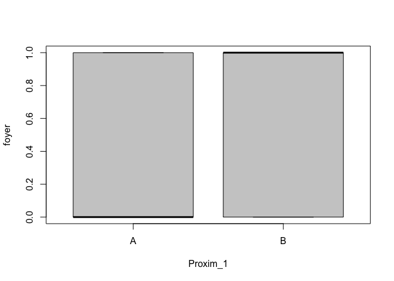

```r
levels(DF$Proxim_1) = c("B","A",rep("B",2))
DF$Proxim_1 = relevel(DF$Proxim_1,"A")
with(data = DF, boxplot(foyer~Proxim_1,cex=.5,col=grey(.8)))
```

```r
reg_Proxim_1 = glm(foyer~Proxim_1,data = DF,family = binomial(link = "logit"))
summary(reg_Proxim_1)
```

```
##
## Call:
## glm(formula = foyer ~ Proxim_1, family = binomial(link = "logit"),
##     data = DF)
##
## Deviance Residuals:
##    Min      1Q  Median      3Q     Max
## -1.209  -1.209   1.146   1.146   1.340
##
## Coefficients:
##             Estimate Std. Error z value Pr(>|z|)
## (Intercept)  -0.3747     0.2261  -1.657   0.0975 .
## Proxim_1B     0.4495     0.2395   1.877   0.0606 .
## ---
## Signif. codes:  0 '***' 0.001 '**' 0.01 '*' 0.05 '.' 0.1 ' ' 1
##
## (Dispersion parameter for binomial family taken to be 1)
##
##     Null deviance: 1002.2  on 722  degrees of freedom
## Residual deviance:  998.6  on 721  degrees of freedom
## AIC: 1002.6
##
## Number of Fisher Scoring iterations: 3
```

Ainsi, nous avons réussi à réduire le nombre de modalités pour la variable Proxim_1 et nous nous retrouvons avec les deux sous-groupes suivants : Proxim_1A, Proxim_1B. Par ailleurs, nous constatons la variable Proxim_1 est n’est pas trop intéressante en raison de sa p-value légèrement élevée. Cependant, nous avons néanmoins décidé de la retenir au cas où elle pourrait soudainement devenir pertinente lorsqu’elle est combinée avec d’autres variables explicatives lors de la construction du modèle.

Où

Proxim_1A = {Artery, RRAe, Feedr, RRAn}

Proxim_1B = {Norm, PosN, PosA}

### (1.1.6) Proxim_2

Ensuite, nous allons procéder au regroupement de la variable Proxim_2 similairement à la méthode utilisée pour combiner les modalités de la variable Zone, c’est-à-dire à l’aide des boîtes à moustaches et du test de Wald.

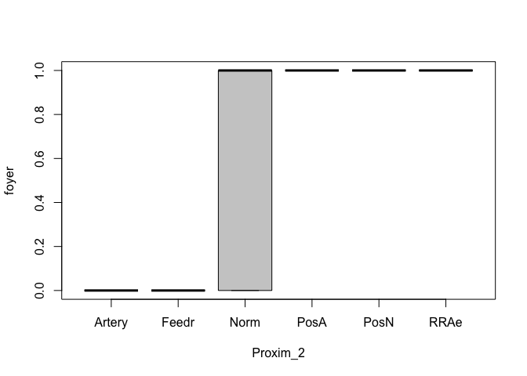

```r
A = with(data = DF, aggregate(foyer,by=list(Proxim_2),FUN=mean))
A = A[order(A$x),]
L = as.character(A$Group.1)
DF$Proxim_2= factor(DF$Proxim_2, level=L)
with(data = DF, boxplot(foyer~Proxim_2,cex=.5,col=grey(.8)))
```

```r
reg_Proxim_2  = glm(foyer~Proxim_2 ,data = DF,family = binomial(link = "logit"))
summary(reg_Proxim_2 )
```

```
##
## Call:
## glm(formula = foyer ~ Proxim_2, family = binomial(link = "logit"),
##     data = DF)
##
## Deviance Residuals:
##    Min      1Q  Median      3Q     Max
## -1.193  -1.193   1.162   1.162   1.162
##
## Coefficients:
##                 Estimate Std. Error z value Pr(>|z|)
## (Intercept)   -1.557e+01  1.455e+03  -0.011    0.991
## Proxim_2Feedr  6.142e-08  1.572e+03   0.000    1.000
## Proxim_2Norm   1.560e+01  1.455e+03   0.011    0.991
## Proxim_2PosA   3.113e+01  2.058e+03   0.015    0.988
## Proxim_2PosN   3.113e+01  2.058e+03   0.015    0.988
## Proxim_2RRAe   3.113e+01  2.058e+03   0.015    0.988
##
## (Dispersion parameter for binomial family taken to be 1)
##
##     Null deviance: 1002.18  on 722  degrees of freedom
## Residual deviance:  988.19  on 717  degrees of freedom
## AIC: 1000.2
##
## Number of Fisher Scoring iterations: 14
```

```r
library(car)
linearHypothesis(reg_Proxim_2, c("Proxim_2Feedr = 0"))
```

```
## Linear hypothesis test
##
## Hypothesis:
## Proxim_2Feedr = 0
##
## Model 1: restricted model
## Model 2: foyer ~ Proxim_2
##
##   Res.Df Df Chisq Pr(>Chisq)
## 1    718
## 2    717  1     0          1
```

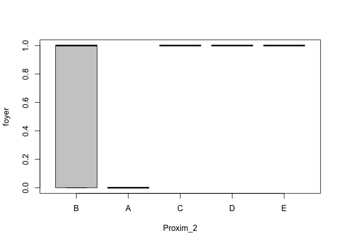

```r
levels(DF$Proxim_2) = c(rep("A",2),"B","C","D","E")
DF$Proxim_2 = relevel(DF$Proxim_2,"B")
with(data = DF, boxplot(foyer~Proxim_2,cex=.5,col=grey(.8)))
```

```r
reg_Proxim_2 = glm(foyer~Proxim_2,data = DF,family = binomial(link = "logit"))
summary(reg_Proxim_2)
```

```
##
## Call:
## glm(formula = foyer ~ Proxim_2, family = binomial(link = "logit"),
##     data = DF)
##
## Deviance Residuals:
##    Min      1Q  Median      3Q     Max
## -1.193  -1.193   1.162   1.162   1.162
##
## Coefficients:
##               Estimate Std. Error z value Pr(>|z|)
## (Intercept)    0.03647    0.07491   0.487    0.626
## Proxim_2A    -15.60254  550.08857  -0.028    0.977
## Proxim_2C     15.52960 1455.39753   0.011    0.991
## Proxim_2D     15.52960 1455.39753   0.011    0.991
## Proxim_2E     15.52960 1455.39753   0.011    0.991
##
## (Dispersion parameter for binomial family taken to be 1)
##
##     Null deviance: 1002.18  on 722  degrees of freedom
## Residual deviance:  988.19  on 718  degrees of freedom
## AIC: 998.19
##
## Number of Fisher Scoring iterations: 14
```

```r
library(car)
linearHypothesis(reg_Proxim_2, c("Proxim_2C = 0",
                                  "Proxim_2D = 0",
                                  "Proxim_2E = 0"))
```

```
## Linear hypothesis test
##
## Hypothesis:
## Proxim_2C = 0
## Proxim_2D = 0
## Proxim_2E = 0
##
## Model 1: restricted model
## Model 2: foyer ~ Proxim_2
##
##   Res.Df Df Chisq Pr(>Chisq)
## 1    721
## 2    718  3 3e-04          1
```

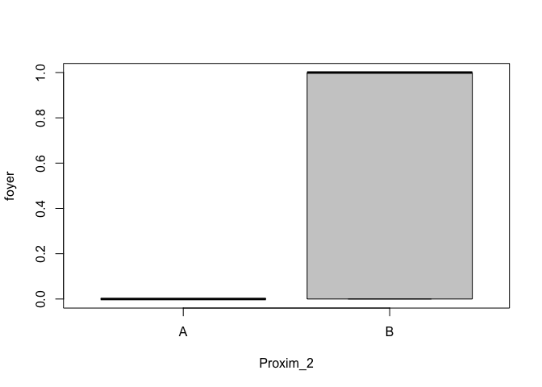

```r
levels(DF$Proxim_2) = c("B","A",rep("B",3))
DF$Proxim_2 = relevel(DF$Proxim_2,"A")
with(data = DF, boxplot(foyer~Proxim_2,cex=.5,col=grey(.8)))
```

```r
reg_Proxim_2 = glm(foyer~Proxim_2,data = DF,family = binomial(link = "logit"))
summary(reg_Proxim_2)
```

```
##
## Call:
## glm(formula = foyer ~ Proxim_2, family = binomial(link = "logit"),
##     data = DF)
##
## Deviance Residuals:
##    Min      1Q  Median      3Q     Max
## -1.196  -1.196   1.158   1.158   1.158
##
## Coefficients:
##             Estimate Std. Error z value Pr(>|z|)
## (Intercept)   -15.57     550.09  -0.028    0.977
## Proxim_2B      15.61     550.09   0.028    0.977
##
## (Dispersion parameter for binomial family taken to be 1)
##
##     Null deviance: 1002.18  on 722  degrees of freedom
## Residual deviance:  992.23  on 721  degrees of freedom
## AIC: 996.23
##
## Number of Fisher Scoring iterations: 14
```

Enfin, nous avons réussi à réduire le nombre de modalités pour la variable Proxim_2 et nous nous retrouvons avec les deux sous-groupes suivants : Proxim_2A, Proxim_2B. Par ailleurs, nous constatons qu’elle ne s’avère pas significative dans la régression logistique. Par conséquent, la variable Proxim_2 n’est pas intéressante en raison de sa p-value trop élevée et nous n’allons pas la retenir pour la construction du modèle.

Où

Proxim_2A = {Artery, Feedr }

Proxim_2B = {Norm, PosN, PosA, RRAe}

### (1.1.7) Logement

Par la suite, nous allons procéder au regroupement de la variable Logement similairement à la méthode utilisée pour combiner les modalités de la variable Zone, c’est-à-dire à l’aide des boîtes à moustaches et du test de Wald.

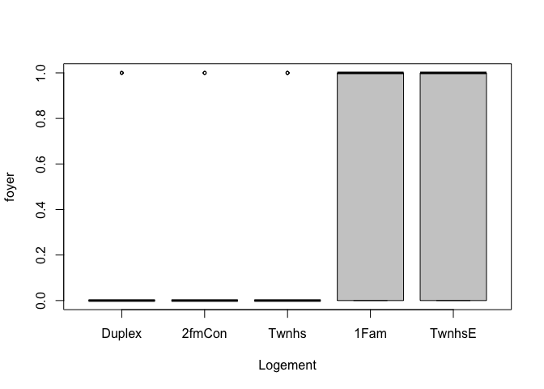

```r
A = with(data = DF, aggregate(foyer,by=list(Logement),FUN=mean))
A = A[order(A$x),]
L = as.character(A$Group.1)
DF$Logement= factor(DF$Logement, level=L)
with(data = DF, boxplot(foyer~Logement,cex=.5,col=grey(.8)))
```

```r
reg_Logement  = glm(foyer~Logement ,data = DF,family = binomial(link = "logit"))
summary(reg_Logement )
```

```
##
## Call:
## glm(formula = foyer ~ Logement, family = binomial(link = "logit"),
##     data = DF)
##
## Deviance Residuals:
##    Min      1Q  Median      3Q     Max
## -1.284  -1.240   1.075   1.116   2.059
##
## Coefficients:
##                Estimate Std. Error z value Pr(>|z|)
## (Intercept)     -1.9924     0.6155  -3.237 0.001206 **
## Logement2fmCon   0.4520     0.8852   0.511 0.609622
## LogementTwnhs    0.6061     0.8314   0.729 0.465986
## Logement1Fam     2.1384     0.6208   3.444 0.000572 ***
## LogementTwnhsE   2.2393     0.6708   3.338 0.000844 ***
## ---
## Signif. codes:  0 '***' 0.001 '**' 0.01 '*' 0.05 '.' 0.1 ' ' 1
##
## (Dispersion parameter for binomial family taken to be 1)
##
##     Null deviance: 1002.18  on 722  degrees of freedom
## Residual deviance:  966.48  on 718  degrees of freedom
## AIC: 976.48
##
## Number of Fisher Scoring iterations: 4
```

```r
library(car)
linearHypothesis(reg_Logement, c("Logement2fmCon = 0",
                                      "LogementTwnhs = 0"))
```

```
## Linear hypothesis test
##
## Hypothesis:
## Logement2fmCon = 0
## LogementTwnhs = 0
##
## Model 1: restricted model
## Model 2: foyer ~ Logement
##
##   Res.Df Df  Chisq Pr(>Chisq)
## 1    720
## 2    718  2 0.5564     0.7571
```

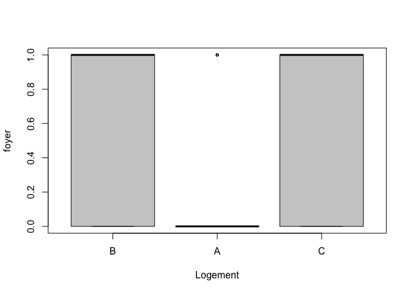

```r
levels(DF$Logement) = c(rep("A",3),"B","C")
DF$Logement = relevel(DF$Logement,"B")
with(data = DF, boxplot(foyer~Logement,cex=.5,col=grey(.8)))
```

```r
reg_Logement = glm(foyer~Logement,data = DF,family = binomial(link = "logit"))
summary(reg_Logement)
```

```
##
## Call:
## glm(formula = foyer ~ Logement, family = binomial(link = "logit"),
##     data = DF)
##
## Deviance Residuals:
##    Min      1Q  Median      3Q     Max
## -1.284  -1.240   1.075   1.116   1.910
##
## Coefficients:
##             Estimate Std. Error z value Pr(>|z|)
## (Intercept)   0.1459     0.0816   1.789   0.0737 .
## LogementA    -1.7946     0.3548  -5.058 4.24e-07 ***
## LogementC     0.1009     0.2791   0.362   0.7177
## ---
## Signif. codes:  0 '***' 0.001 '**' 0.01 '*' 0.05 '.' 0.1 ' ' 1
##
## (Dispersion parameter for binomial family taken to be 1)
##
##     Null deviance: 1002.18  on 722  degrees of freedom
## Residual deviance:  967.05  on 720  degrees of freedom
## AIC: 973.05
##
## Number of Fisher Scoring iterations: 3
```

```r
library(car)
linearHypothesis(reg_Logement, c("LogementC = 0"))
```

```
## Linear hypothesis test
##
## Hypothesis:
## LogementC = 0
##
## Model 1: restricted model
## Model 2: foyer ~ Logement
##
##   Res.Df Df  Chisq Pr(>Chisq)
## 1    721
## 2    720  1 0.1307     0.7177
```

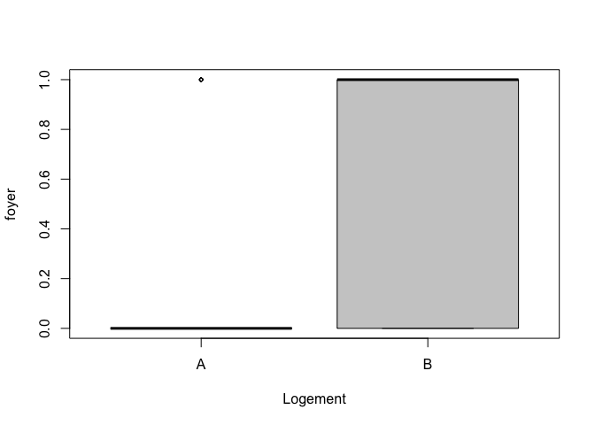

```r
levels(DF$Logement) = c("B","A","B")
DF$Logement = relevel(DF$Logement,"A")
with(data = DF, boxplot(foyer~Logement,cex=.5,col=grey(.8)))
```

```r
reg_Logement = glm(foyer~Logement,data = DF,family = binomial(link = "logit"))
summary(reg_Logement)
```

```
##
## Call:
## glm(formula = foyer ~ Logement, family = binomial(link = "logit"),
##     data = DF)
##
## Deviance Residuals:
##    Min      1Q  Median      3Q     Max
## -1.244  -1.244   1.113   1.113   1.910
##
## Coefficients:
##             Estimate Std. Error z value Pr(>|z|)
## (Intercept)  -1.6487     0.3453  -4.775 1.80e-06 ***
## LogementB     1.8033     0.3540   5.094 3.51e-07 ***
## ---
## Signif. codes:  0 '***' 0.001 '**' 0.01 '*' 0.05 '.' 0.1 ' ' 1
##
## (Dispersion parameter for binomial family taken to be 1)
##
##     Null deviance: 1002.18  on 722  degrees of freedom
## Residual deviance:  967.19  on 721  degrees of freedom
## AIC: 971.19
##
## Number of Fisher Scoring iterations: 3
```

Enfin, nous avons réussi à réduire le nombre de modalités pour la variable Logement et nous nous retrouvons avec les deux sous-groupes suivants : LogementA, LogementB. Par ailleurs, nous constatons qu’elle s’avère significative dans la régression logistique. De ce fait, la variable Logement est très intéressante en raison de sa faible p-value et nous allons la retenir pour la construction du modèle.

Où

LogementA = {Buplex, 2fmCon, Twnhs}

LogementB = {1Fam, TwnhsE}

### (1.1.8) Style

Encore une fois, nous allons procéder au regroupement de la variable Style similairement à la méthode utilisée pour combiner les modalités de la variable Zone, c’est-à-dire à l’aide des boîtes à moustaches et du test de Wald.

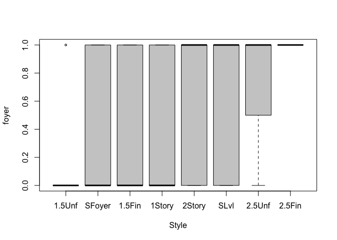

```r
A = with(data = DF, aggregate(foyer,by=list(Style),FUN=mean))
A = A[order(A$x),]
L = as.character(A$Group.1)
DF$Style= factor(DF$Style, level=L)
with(data = DF, boxplot(foyer~Style,cex=.5,col=grey(.8)))
```

```r
reg_Style = glm(foyer~Style ,data = DF,family = binomial(link = "logit"))
summary(reg_Style)
```

```
##
## Call:
## glm(formula = foyer ~ Style, family = binomial(link = "logit"),
##     data = DF)
##
## Deviance Residuals:
##     Min       1Q   Median       3Q      Max
## -1.5829  -1.1372   0.8203   1.2181   1.9728
##
## Coefficients:
##             Estimate Std. Error z value Pr(>|z|)
## (Intercept)  -1.7918     1.0801  -1.659   0.0971 .
## StyleSFoyer   0.9445     1.1852   0.797   0.4255
## Style1.5Fin   1.3304     1.1058   1.203   0.2289
## Style1Story   1.6964     1.0850   1.564   0.1179
## Style2Story   2.2134     1.0894   2.032   0.0422 *
## StyleSLvl     2.5390     1.1534   2.201   0.0277 *
## Style2.5Unf   2.7081     1.3663   1.982   0.0475 *
## Style2.5Fin  15.3578   535.4123   0.029   0.9771
## ---
## Signif. codes:  0 '***' 0.001 '**' 0.01 '*' 0.05 '.' 0.1 ' ' 1
##
## (Dispersion parameter for binomial family taken to be 1)
##
##     Null deviance: 1002.18  on 722  degrees of freedom
## Residual deviance:  974.93  on 715  degrees of freedom
## AIC: 990.93
##
## Number of Fisher Scoring iterations: 12
```

```r
library(car)
linearHypothesis(reg_Style, c("StyleSFoyer = 0",
                                  "Style1.5Fin = 0",
                                  "Style1Story = 0"))
```

```
## Linear hypothesis test
##
## Hypothesis:
## StyleSFoyer = 0
## Style1.5Fin = 0
## Style1Story = 0
##
## Model 1: restricted model
## Model 2: foyer ~ Style
##
##   Res.Df Df  Chisq Pr(>Chisq)
## 1    718
## 2    715  3 6.1687     0.1037
```

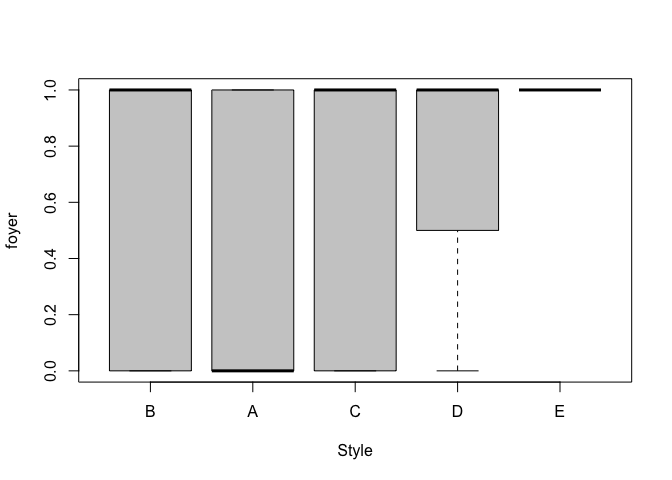

```r
levels(DF$Style) = c(rep("A",4),"B","C","D","E")
DF$Style = relevel(DF$Style,"B")
with(data = DF, boxplot(foyer~Style,cex=.5,col=grey(.8)))
```

```r
reg_Style = glm(foyer~Style ,data = DF,family = binomial(link = "logit"))
summary(reg_Style)
```

```
##
## Call:
## glm(formula = foyer ~ Style, family = binomial(link = "logit"),
##     data = DF)
##
## Deviance Residuals:
##     Min       1Q   Median       3Q      Max
## -1.5829  -1.0935   0.8203   1.2637   1.2637
##
## Coefficients:
##             Estimate Std. Error z value Pr(>|z|)
## (Intercept)   0.4216     0.1421   2.967 0.003010 **
## StyleA       -0.6223     0.1692  -3.679 0.000234 ***
## StyleC        0.3256     0.4289   0.759 0.447713
## StyleD        0.4947     0.8486   0.583 0.559943
## StyleE       13.1445   535.4112   0.025 0.980414
## ---
## Signif. codes:  0 '***' 0.001 '**' 0.01 '*' 0.05 '.' 0.1 ' ' 1
##
## (Dispersion parameter for binomial family taken to be 1)
##
##     Null deviance: 1002.18  on 722  degrees of freedom
## Residual deviance:  982.12  on 718  degrees of freedom
## AIC: 992.12
##
## Number of Fisher Scoring iterations: 12
```

```r
library(car)
linearHypothesis(reg_Style, c("StyleC = 0",
                              "StyleD = 0",
                              "StyleE = 0"))
```

```
## Linear hypothesis test
##
## Hypothesis:
## StyleC = 0
## StyleD = 0
## StyleE = 0
##
## Model 1: restricted model
## Model 2: foyer ~ Style
##
##   Res.Df Df  Chisq Pr(>Chisq)
## 1    721
## 2    718  3 0.8704     0.8326
```

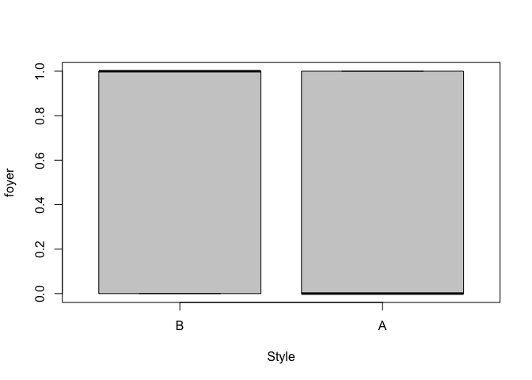

```r
levels(DF$Style) = c("B","A",rep("B",3))
DF$Style = relevel(DF$Style,"B")
with(data = DF, boxplot(foyer~Style,cex=.5,col=grey(.8)))
```

```r
reg_Style = glm(foyer~Style ,data = DF,family = binomial(link = "logit"))
summary(reg_Style)
```

```
##
## Call:
## glm(formula = foyer ~ Style, family = binomial(link = "logit"),
##     data = DF)
##
## Deviance Residuals:
##     Min       1Q   Median       3Q      Max
## -1.3860  -1.0935   0.9823   1.2637   1.2637
##
## Coefficients:
##             Estimate Std. Error z value Pr(>|z|)
## (Intercept)   0.4780     0.1320   3.622 0.000292 ***
## StyleA       -0.6787     0.1607  -4.222 2.42e-05 ***
## ---
## Signif. codes:  0 '***' 0.001 '**' 0.01 '*' 0.05 '.' 0.1 ' ' 1
##
## (Dispersion parameter for binomial family taken to be 1)
##
##     Null deviance: 1002.18  on 722  degrees of freedom
## Residual deviance:  983.99  on 721  degrees of freedom
## AIC: 987.99
##
## Number of Fisher Scoring iterations: 4
```

Enfin, nous avons réussi à réduire le nombre de modalités pour la variable Style et nous nous retrouvons avec les deux sous-groupes suivants : StyleA, StyleB. Par ailleurs, nous constatons qu’elle s’avère significative dans la régression logistique. De ce fait, la variable Style est très intéressante en raison de sa faible p-value et nous allons la retenir pour la construction du modèle.

Où

StyleA = {1.5Unf, SFoyer, 1.5Fin, 1Story}

StyleB = {2Story, SLvl, 2.5Unf, 2.5Fin}

### (1.1.9) Toit

Par la suite, nous allons procéder au regroupement de la variable Toit similairement à la méthode utilisée pour combiner les modalités de la variable Zone, c’est-à-dire à l’aide des boîtes à moustaches et du test de Wald.

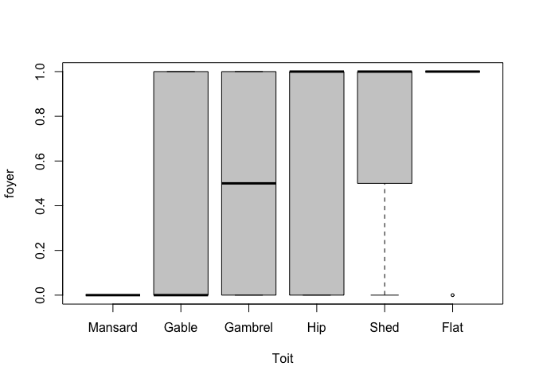

```r
A = with(data = DF, aggregate(foyer,by=list(Toit),FUN=mean))
A = A[order(A$x),]
L = as.character(A$Group.1)
DF$Toit= factor(DF$Toit, level=L)
with(data = DF, boxplot(foyer~Toit,cex=.5,col=grey(.8)))
```

```r
reg_Toit = glm(foyer~Toit,data = DF,family = binomial(link = "logit"))
summary(reg_Toit )
```

```
##
## Call:
## glm(formula = foyer ~ Toit, family = binomial(link = "logit"),
##     data = DF)
##
## Deviance Residuals:
##     Min       1Q   Median       3Q      Max
## -1.7941  -1.1213   0.9005   1.2346   1.2346
##
## Coefficients:
##             Estimate Std. Error z value Pr(>|z|)
## (Intercept)   -13.57     535.41  -0.025    0.980
## ToitGable      13.43     535.41   0.025    0.980
## ToitGambrel    13.57     535.41   0.025    0.980
## ToitHip        14.22     535.41   0.027    0.979
## ToitShed       14.26     535.41   0.027    0.979
## ToitFlat       14.95     535.41   0.028    0.978
##
## (Dispersion parameter for binomial family taken to be 1)
##
##     Null deviance: 1002.18  on 722  degrees of freedom
## Residual deviance:  982.04  on 717  degrees of freedom
## AIC: 994.04
##
## Number of Fisher Scoring iterations: 12
```

```r
library(car)
linearHypothesis(reg_Toit, c("ToitGable = 0",
                             "ToitGambrel = 0"))
```

```
## Linear hypothesis test
##
## Hypothesis:
## ToitGable = 0
## ToitGambrel = 0
##
## Model 1: restricted model
## Model 2: foyer ~ Toit
##
##   Res.Df Df  Chisq Pr(>Chisq)
## 1    719
## 2    717  2 0.0183     0.9909
```

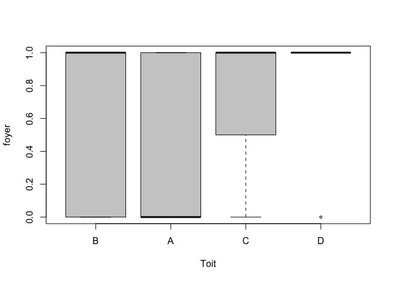

```r
levels(DF$Toit) = c(rep("A",3),"B","C","D")
DF$Toit = relevel(DF$Toit,"B")
with(data = DF, boxplot(foyer~Toit,cex=.5,col=grey(.8)))
```

```r
reg_Toit = glm(foyer~Toit ,data = DF,family = binomial(link = "logit"))
summary(reg_Toit)
```

```
##
## Call:
## glm(formula = foyer ~ Toit, family = binomial(link = "logit"),
##     data = DF)
##
## Deviance Residuals:
##     Min       1Q   Median       3Q      Max
## -1.7941  -1.1203   0.9005   1.2356   1.2356
##
## Coefficients:
##             Estimate Std. Error z value Pr(>|z|)
## (Intercept)  0.65059    0.17805   3.654 0.000258 ***
## ToitA       -0.78645    0.19670  -3.998 6.38e-05 ***
## ToitC        0.04256    1.23762   0.034 0.972568
## ToitD        0.73571    1.13212   0.650 0.515791
## ---
## Signif. codes:  0 '***' 0.001 '**' 0.01 '*' 0.05 '.' 0.1 ' ' 1
##
## (Dispersion parameter for binomial family taken to be 1)
##
##     Null deviance: 1002.18  on 722  degrees of freedom
## Residual deviance:  983.31  on 719  degrees of freedom
## AIC: 991.31
##
## Number of Fisher Scoring iterations: 4
```

```r
library(car)
linearHypothesis(reg_Toit, c("ToitC = 0",
                             "ToitD = 0"))
```

```
## Linear hypothesis test
##
## Hypothesis:
## ToitC = 0
## ToitD = 0
##
## Model 1: restricted model
## Model 2: foyer ~ Toit
##
##   Res.Df Df  Chisq Pr(>Chisq)
## 1    721
## 2    719  2 0.4227     0.8095
```

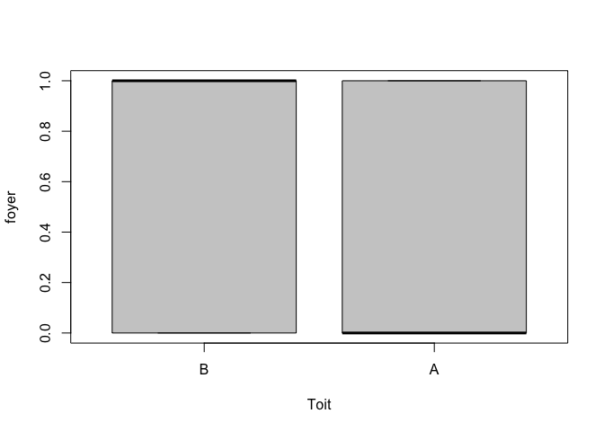

```r
levels(DF$Toit) = c("B","A",rep("B",2))
DF$Toit = relevel(DF$Toit,"B")
with(data = DF, boxplot(foyer~Toit,cex=.5,col=grey(.8)))
```

```r
reg_Toit = glm(foyer~Toit ,data = DF,family = binomial(link = "logit"))
summary(reg_Toit)
```

```
##
## Call:
## glm(formula = foyer ~ Toit, family = binomial(link = "logit"),
##     data = DF)
##
## Deviance Residuals:
##    Min      1Q  Median      3Q     Max
## -1.473  -1.120   0.908   1.236   1.236
##
## Coefficients:
##             Estimate Std. Error z value Pr(>|z|)
## (Intercept)   0.6729     0.1738   3.872 0.000108 ***
## ToitA        -0.8088     0.1929  -4.194 2.74e-05 ***
## ---
## Signif. codes:  0 '***' 0.001 '**' 0.01 '*' 0.05 '.' 0.1 ' ' 1
##
## (Dispersion parameter for binomial family taken to be 1)
##
##     Null deviance: 1002.18  on 722  degrees of freedom
## Residual deviance:  983.79  on 721  degrees of freedom
## AIC: 987.79
##
## Number of Fisher Scoring iterations: 4
```

Enfin, nous avons réussi à réduire le nombre de modalités pour la variable Toit et nous nous retrouvons avec les deux sous-groupes suivants : ToitA, ToitB. Par ailleurs, nous constatons qu’elle s’avère significative dans la régression logistique. De ce fait, la variable Toit est très intéressante en raison de sa faible p-value et nous allons la retenir pour la construction du modèle.

Où

ToitA = {Mansard, Gable, Gambrel}

ToitB = {Hip, Shed, Flat}

### (1.1.10) Exterieur

Encore une fois, nous allons procéder au regroupement de la variable Exterieur similairement à la méthode utilisée pour combiner les modalités de la variable Zone, c’est-à-dire à l’aide des boîtes à moustaches et du test de Wald.

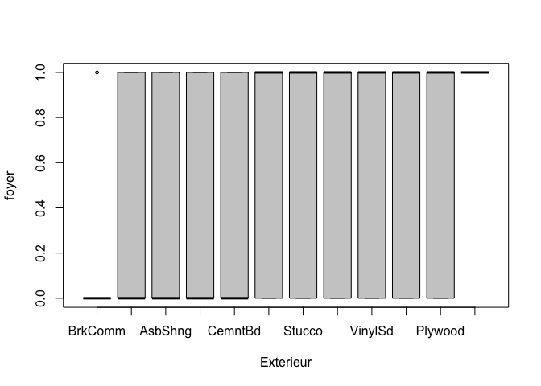

```r
A = with(data = DF, aggregate(foyer,by=list(Exterieur),FUN=mean))
A = A[order(A$x),]
L = as.character(A$Group.1)
DF$Exterieur= factor(DF$Exterieur, level=L)
with(data = DF, boxplot(foyer~Exterieur,cex=.5,col=grey(.8)))
```

```r
reg_Exterieur = glm(foyer~Exterieur,data = DF,family = binomial(link = "logit"))
summary(reg_Exterieur)
```

```
##
## Call:
## glm(formula = foyer ~ Exterieur, family = binomial(link = "logit"),
##     data = DF)
##
## Deviance Residuals:
##     Min       1Q   Median       3Q      Max
## -1.4689  -1.1985   0.9116   1.0108   1.7941
##
## Coefficients:
##                  Estimate Std. Error z value Pr(>|z|)
## (Intercept)       -1.3863     1.1180  -1.240   0.2150
## ExterieurMetalSd   0.4495     1.1393   0.395   0.6932
## ExterieurAsbShng   0.4700     1.2649   0.372   0.7102
## ExterieurHdBoard   1.0929     1.1356   0.962   0.3358
## ExterieurCemntBd   1.3218     1.1744   1.125   0.2604
## ExterieurWd Sdng   1.4359     1.1327   1.268   0.2049
## ExterieurStucco    1.5404     1.2488   1.234   0.2174
## ExterieurWdShing   1.5686     1.2715   1.234   0.2173
## ExterieurVinylSd   1.7918     1.1255   1.592   0.1114
## ExterieurBrkFace   2.0053     1.2123   1.654   0.0981 .
## ExterieurPlywood   2.0496     1.1572   1.771   0.0765 .
## ExterieurStone    14.9524   378.5945   0.039   0.9685
## ---
## Signif. codes:  0 '***' 0.001 '**' 0.01 '*' 0.05 '.' 0.1 ' ' 1
##
## (Dispersion parameter for binomial family taken to be 1)
##
##     Null deviance: 1002.18  on 722  degrees of freedom
## Residual deviance:  955.02  on 711  degrees of freedom
## AIC: 979.02
##
## Number of Fisher Scoring iterations: 12
```

```r
library(car)
linearHypothesis(reg_Exterieur, c("ExterieurMetalSd = 0",
                             "ExterieurAsbShng = 0",
                             "ExterieurHdBoard = 0",
                             "ExterieurCemntBd = 0"))
```

```
## Linear hypothesis test
##
## Hypothesis:
## ExterieurMetalSd = 0
## ExterieurAsbShng = 0
## ExterieurHdBoard = 0
## ExterieurCemntBd = 0
##
## Model 1: restricted model
## Model 2: foyer ~ Exterieur
##
##   Res.Df Df  Chisq Pr(>Chisq)
## 1    715
## 2    711  4 7.5407     0.1099
```

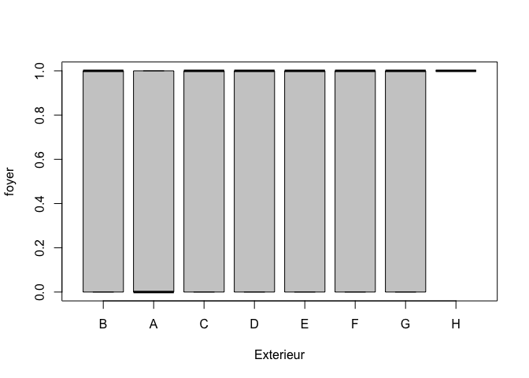

```r
levels(DF$Exterieur) = c(rep("A",5),"B","C","D","E","F","G","H")
DF$Exterieur = relevel(DF$Exterieur,"B")
with(data = DF, boxplot(foyer~Exterieur,cex=.5,col=grey(.8)))
```

```r
reg_Exterieur = glm(foyer~Exterieur,data = DF,family = binomial(link = "logit"))
summary(reg_Exterieur)
```

```
##
## Call:
## glm(formula = foyer ~ Exterieur, family = binomial(link = "logit"),
##     data = DF)
##
## Deviance Residuals:
##     Min       1Q   Median       3Q      Max
## -1.4689  -1.1985   0.9116   1.0108   1.4231
##
## Coefficients:
##             Estimate Std. Error z value Pr(>|z|)
## (Intercept)   0.0496     0.1819   0.273  0.78508
## ExterieurA   -0.6108     0.2235  -2.732  0.00629 **
## ExterieurC    0.1046     0.5853   0.179  0.85823
## ExterieurD    0.1327     0.6322   0.210  0.83373
## ExterieurE    0.3559     0.2230   1.596  0.11059
## ExterieurF    0.5694     0.5029   1.132  0.25745
## ExterieurG    0.6137     0.3496   1.756  0.07917 .
## ExterieurH   13.5165   378.5929   0.036  0.97152
## ---
## Signif. codes:  0 '***' 0.001 '**' 0.01 '*' 0.05 '.' 0.1 ' ' 1
##
## (Dispersion parameter for binomial family taken to be 1)
##
##     Null deviance: 1002.18  on 722  degrees of freedom
## Residual deviance:  962.78  on 715  degrees of freedom
## AIC: 978.78
##
## Number of Fisher Scoring iterations: 12
```

```r
library(car)
linearHypothesis(reg_Exterieur, c("ExterieurC = 0",
                             "ExterieurD = 0",
                             "ExterieurE = 0",
                             "ExterieurF = 0",
                             "ExterieurG = 0",
                             "ExterieurH = 0"))
```

```
## Linear hypothesis test
##
## Hypothesis:
## ExterieurC = 0
## ExterieurD = 0
## ExterieurE = 0
## ExterieurF = 0
## ExterieurG = 0
## ExterieurH = 0
##
## Model 1: restricted model
## Model 2: foyer ~ Exterieur
##
##   Res.Df Df  Chisq Pr(>Chisq)
## 1    721
## 2    715  6 4.5056     0.6086
```

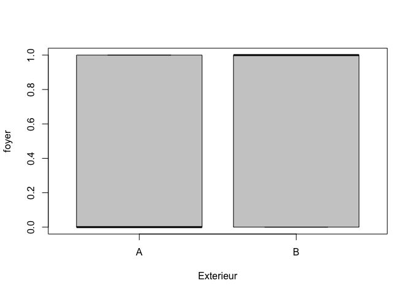

```r
levels(DF$Exterieur) = c("B","A",rep("B",6))
DF$Exterieur = relevel(DF$Exterieur,"A")
with(data = DF, boxplot(foyer~Exterieur,cex=.5,col=grey(.8)))
```

```r
reg_Exterieur = glm(foyer~Exterieur,data = DF,family = binomial(link = "logit"))
summary(reg_Exterieur)
```

```
##
## Call:
## glm(formula = foyer ~ Exterieur, family = binomial(link = "logit"),
##     data = DF)
##
## Deviance Residuals:
##    Min      1Q  Median      3Q     Max
## -1.325  -1.325   1.036   1.036   1.423
##
## Coefficients:
##             Estimate Std. Error z value Pr(>|z|)
## (Intercept)  -0.5612     0.1300  -4.318 1.57e-05 ***
## ExterieurB    0.9028     0.1603   5.631 1.79e-08 ***
## ---
## Signif. codes:  0 '***' 0.001 '**' 0.01 '*' 0.05 '.' 0.1 ' ' 1
##
## (Dispersion parameter for binomial family taken to be 1)
##
##     Null deviance: 1002.18  on 722  degrees of freedom
## Residual deviance:  969.48  on 721  degrees of freedom
## AIC: 973.48
##
## Number of Fisher Scoring iterations: 4
```

Enfin, nous avons réussi à réduire le nombre de modalités pour la variable Extérieur et nous nous retrouvons avec les deux sous-groupes suivants : ExterieurA, ExterieurB. Par ailleurs, nous constatons qu’elle s’avère significative dans la régression logistique. De ce fait, cette variable est très intéressante en raison de sa faible p-value et nous allons la retenir pour la construction du modèle.

### (1.1.11) Maconnerie

Ensuite, nous allons procéder au regroupement de la variable Maconnerie similairement à la méthode utilisée pour combiner les modalités de la variable Zone, c’est-à-dire à l’aide des boîtes à moustaches et du test de Wald.

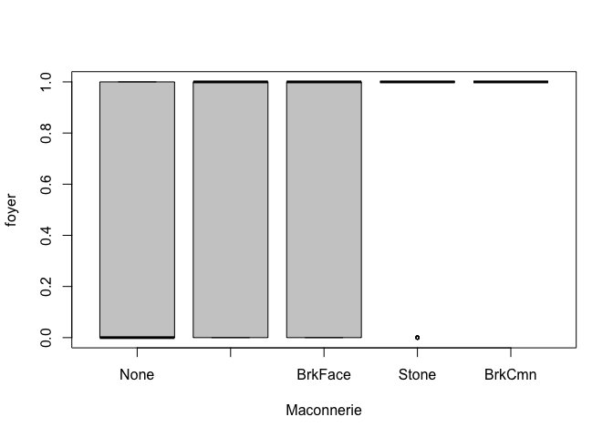

```r
A = with(data = DF, aggregate(foyer,by=list(Maconnerie),FUN=mean))
A = A[order(A$x),]
L = as.character(A$Group.1)
DF$Maconnerie= factor(DF$Maconnerie, level=L)
with(data = DF, boxplot(foyer~Maconnerie,cex=.5,col=grey(.8)))
```

```r
reg_Maconnerie= glm(foyer~Maconnerie,data = DF,family = binomial(link = "logit"))
summary(reg_Maconnerie)
```

```
##
## Call:
## glm(formula = foyer ~ Maconnerie, family = binomial(link = "logit"),
##     data = DF)
##
## Deviance Residuals:
##     Min       1Q   Median       3Q      Max
## -1.9214  -0.9900   0.5863   0.9161   1.3772
##
## Coefficients:
##                    Estimate Std. Error z value Pr(>|z|)
## (Intercept)        -0.45831    0.09742  -4.705 2.54e-06 ***
## Maconnerie          0.96913    0.73677   1.315    0.188
## MaconnerieBrkFace   1.10949    0.17416   6.371 1.88e-10 ***
## MaconnerieStone     2.13228    0.37608   5.670 1.43e-08 ***
## MaconnerieBrkCmn   14.02437  535.41118   0.026    0.979
## ---
## Signif. codes:  0 '***' 0.001 '**' 0.01 '*' 0.05 '.' 0.1 ' ' 1
##
## (Dispersion parameter for binomial family taken to be 1)
##
##     Null deviance: 1002.18  on 722  degrees of freedom
## Residual deviance:  926.95  on 718  degrees of freedom
## AIC: 936.95
##
## Number of Fisher Scoring iterations: 12
```

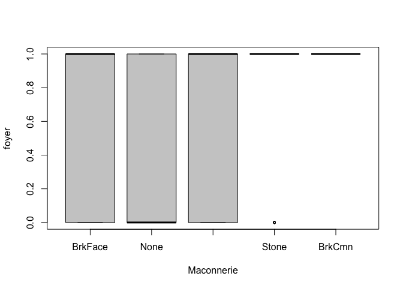

```r
DF$Maconnerie = relevel(DF$Maconnerie,"BrkFace")
with(data = DF, boxplot(foyer~Maconnerie,cex=.5,col=grey(.8)))
```

```r
reg_Maconnerie= glm(foyer~Maconnerie,data = DF,family = binomial(link = "logit"))
summary(reg_Maconnerie)
```

```
##
## Call:
## glm(formula = foyer ~ Maconnerie, family = binomial(link = "logit"),
##     data = DF)
##
## Deviance Residuals:
##     Min       1Q   Median       3Q      Max
## -1.9214  -0.9900   0.5863   0.9161   1.3772
##
## Coefficients:
##                  Estimate Std. Error z value Pr(>|z|)
## (Intercept)        0.6512     0.1444   4.511 6.46e-06 ***
## MaconnerieNone    -1.1095     0.1742  -6.371 1.88e-10 ***
## Maconnerie        -0.1404     0.7444  -0.189  0.85045
## MaconnerieStone    1.0228     0.3909   2.617  0.00888 **
## MaconnerieBrkCmn  12.9149   535.4112   0.024  0.98076
## ---
## Signif. codes:  0 '***' 0.001 '**' 0.01 '*' 0.05 '.' 0.1 ' ' 1
##
## (Dispersion parameter for binomial family taken to be 1)
##
##     Null deviance: 1002.18  on 722  degrees of freedom
## Residual deviance:  926.95  on 718  degrees of freedom
## AIC: 936.95
##
## Number of Fisher Scoring iterations: 12
```

```r
library(car)
linearHypothesis(reg_Maconnerie, c("Maconnerie = 0",
                             "MaconnerieBrkCmn = 0"))
```

```
## Linear hypothesis test
##
## Hypothesis:
## Maconnerie = 0
## MaconnerieBrkCmn = 0
##
## Model 1: restricted model
## Model 2: foyer ~ Maconnerie
##
##   Res.Df Df  Chisq Pr(>Chisq)
## 1    720
## 2    718  2 0.0361     0.9821
```

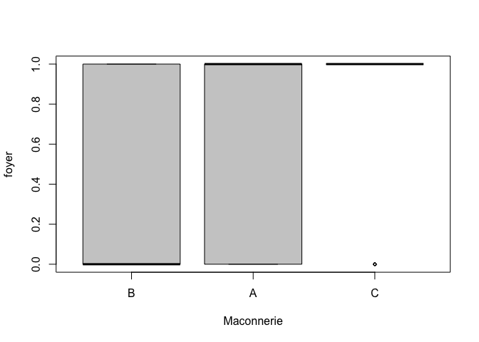

```r
levels(DF$Maconnerie) = c("A","B","A","C","A")
DF$Maconnerie = relevel(DF$Maconnerie,"B")
with(data = DF, boxplot(foyer~Maconnerie,cex=.5,col=grey(.8)))
```

```r
reg_Maconnerie= glm(foyer~Maconnerie,data = DF,family = binomial(link = "logit"))
summary(reg_Maconnerie)
```

```
##
## Call:
## glm(formula = foyer ~ Maconnerie, family = binomial(link = "logit"),
##     data = DF)
##
## Deviance Residuals:
##     Min       1Q   Median       3Q      Max
## -1.9214  -0.9900   0.5863   0.9155   1.3772
##
## Coefficients:
##             Estimate Std. Error z value Pr(>|z|)
## (Intercept) -0.45831    0.09742  -4.705 2.54e-06 ***
## MaconnerieA  1.11118    0.17175   6.470 9.81e-11 ***
## MaconnerieC  2.13228    0.37608   5.670 1.43e-08 ***
## ---
## Signif. codes:  0 '***' 0.001 '**' 0.01 '*' 0.05 '.' 0.1 ' ' 1
##
## (Dispersion parameter for binomial family taken to be 1)
##
##     Null deviance: 1002.18  on 722  degrees of freedom
## Residual deviance:  927.82  on 720  degrees of freedom
## AIC: 933.82
##
## Number of Fisher Scoring iterations: 4
```

Enfin, nous avons réussi à réduire le nombre de modalités pour la variable Maconnerie et nous nous retrouvons avec les trois sous-groupes suivants : MaconnerieA, MaconnerieB, Maconnerie C. Par ailleurs, nous constatons qu’elle s’avère significative dans la régression logistique. De ce fait, cette variable est très intéressante en raison de sa faible p-value et nous allons la retenir pour la construction du modèle.

Où

MaconnerieA = {BrkFace, , BrkCmn}

MaconnerieB = {None}

MaconnerieC = {Stone}